# Hw7

Calvin Wong

4/17/2020

6.2. Developing a model to predict permeability (see Sect. 1.4) could save significant resources for a pharmaceutical company, while at the same time more rapidly identifying molecules that have a sufficient permeability to become a drug:

1. Start R and use these commands to load the data: > library(AppliedPredictiveModeling) > data(permeability) The matrix fingerprints contains the 1,107 binary molecular predictors for the 165 compounds, while permeability contains permeability response.

```r
library(caret)
library(AppliedPredictiveModeling)

data(permeability)
str(permeability)
```

```
##  num [1:165, 1] 12.52 1.12 19.41 1.73 1.68 ...
##  - attr(*, "dimnames")=List of 2
##   ..$ : chr [1:165] "1" "2" "3" "4" ...
##   ..$ : chr "permeability"
```

2. The fingerprint predictors indicate the presence or absence of substructures of a molecule and are often sparse meaning that relatively few of the molecules contain each substructure. Filter out the predictors that have low frequencies using the nearZeroVar function from the caret package. How many predictors are left for modeling?

388 Predictors are left for modeling

```r
lowfreq <- nearZeroVar(fingerprints)
X <- fingerprints[,-lowfreq]
str(X)
```

```
##  num [1:165, 1:388] 0 0 0 0 0 0 0 0 0 0 ...
##  - attr(*, "dimnames")=List of 2
##   ..$ : chr [1:165] "1" "2" "3" "4" ...
##   ..$ : chr [1:388] "X1" "X2" "X3" "X4" ...
```

```r
#388
```

3. Split the data into a training and a test set, pre-process the data, and tune a PLS model. How many latent variables are optimal and what is the corresponding resampled estimate of R2?

```r
set.seed(17)
trainRow <- createDataPartition(permeability, p=0.8, list=FALSE)
X.train <- X[trainRow, ]
y.train <- permeability[trainRow, ]
X.test <- X[-trainRow, ]
y.test <- permeability[-trainRow, ]
```

```r
set.seed(17)
plsFit <- train(x=X.train,
                y=y.train,
                method='pls',
                metric='Rsquared',
                tuneLength=20,
                trControl=trainControl(method='cv'),
                preProcess=c('center', 'scale')
                )

plsResult <- plsFit$results
plsFit
```

```
## Partial Least Squares
##
## 133 samples
## 388 predictors
##
## Pre-processing: centered (388), scaled (388)
## Resampling: Cross-Validated (10 fold)
## Summary of sample sizes: 121, 121, 121, 120, 120, 118, ...
## Resampling results across tuning parameters:
##
##   ncomp  RMSE      Rsquared   MAE
##    1     13.24375  0.3451453  10.072900
##    2     12.18212  0.4642943   8.580056
##    3     12.04035  0.4747734   8.997801
##    4     11.88987  0.4833083   9.204068
##    5     11.90115  0.4793076   9.086845
##    6     11.61736  0.4977123   8.733841
##    7     11.73219  0.4943145   8.899556
##    8     11.62560  0.4968656   8.886937
##    9     11.94640  0.4815852   8.996081
##   10     12.12844  0.4645216   9.211748
##   11     12.37340  0.4561691   9.202411
##   12     12.47796  0.4437635   9.255495
##   13     12.72324  0.4283049   9.516754
##   14     12.87195  0.4185651   9.524039
##   15     13.08794  0.4137176   9.592794
##   16     13.53823  0.3965190   9.767638
##   17     13.88915  0.3817657   9.872228
##   18     13.91568  0.3848705   9.775784
##   19     13.99503  0.3839630   9.765094
##   20     14.19839  0.3733161   9.897477
##
## Rsquared was used to select the optimal model using the largest value.
## The final value used for the model was ncomp = 6.
```

4. Predict the response for the test set. What is the test set estimate of R2?

The R2 test set estimate is 0.2986943.

```r
plsPred <- predict(plsFit, newdata=X.test)
postResample(pred=plsPred, obs=y.test)
```

```
##       RMSE   Rsquared        MAE
## 13.2202593  0.2986943  9.8944528
```

5. Try building other models discussed in this chapter. Do any have betteryes predictive performance?

```r
set.seed(17)
ridgeFit <- train(x=X.train,
                  y=y.train,
                  method='ridge',
                  metric='Rsquared',
                  tuneGrid=data.frame(.lambda = seq(0, 1, by=0.1)),
                  trControl=trainControl(method='cv'),
                  preProcess=c('center','scale')
                  )
ridgeFit
```

```
## Ridge Regression
##
## 133 samples
## 388 predictors
##
## Pre-processing: centered (388), scaled (388)
## Resampling: Cross-Validated (10 fold)
## Summary of sample sizes: 121, 121, 121, 120, 120, 118, ...
## Resampling results across tuning parameters:
##
##   lambda  RMSE      Rsquared   MAE
##   0.0     15.81893  0.3454468  11.662713
##   0.1     12.72608  0.4496851   9.251809
##   0.2     12.56214  0.4797825   9.324701
##   0.3     12.72928  0.4953146   9.528184
##   0.4     13.05548  0.5048587   9.814497
##   0.5     13.47974  0.5108798  10.134119
##   0.6     13.98261  0.5151149  10.540405
##   0.7     14.54496  0.5180570  11.003768
##   0.8     15.15480  0.5201236  11.507481
##   0.9     15.80364  0.5215557  12.038093
##   1.0     16.48437  0.5225234  12.569617
##
## Rsquared was used to select the optimal model using the largest value.
## The final value used for the model was lambda = 1.
```

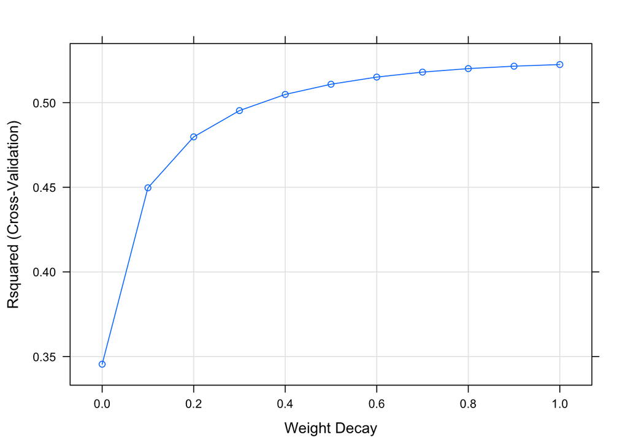

```r
plot(ridgeFit)
```

```r
set.seed(17)
lassoFit <- train(x=X.train,
                  y=y.train,
                  method='lasso',
                  metric='Rsquared',
                  tuneGrid=data.frame(.fraction = seq(0, 0.5, by=0.05)),
                  trControl=trainControl(method='cv'),
                  preProcess=c('center','scale')
                  )
lassoFit
```

```
## The lasso
##
## 133 samples
## 388 predictors
##
## Pre-processing: centered (388), scaled (388)
## Resampling: Cross-Validated (10 fold)
## Summary of sample sizes: 121, 121, 121, 120, 120, 118, ...
## Resampling results across tuning parameters:
##
##   fraction  RMSE      Rsquared   MAE
##   0.00      15.77393        NaN  12.566979
##   0.05      11.76910  0.5459518   9.082913
##   0.10      11.19661  0.5395927   8.431876
##   0.15      10.95817  0.5370482   8.160485
##   0.20      11.04148  0.5247033   8.209331
##   0.25      11.20424  0.5176492   8.377139
##   0.30      11.47931  0.5057548   8.595281
##   0.35      11.69333  0.4963916   8.717847
##   0.40      11.90052  0.4883951   8.864456
##   0.45      12.22369  0.4742570   9.082750
##   0.50      12.46726  0.4638424   9.225296
##
## Rsquared was used to select the optimal model using the largest value.
## The final value used for the model was fraction = 0.05.
```

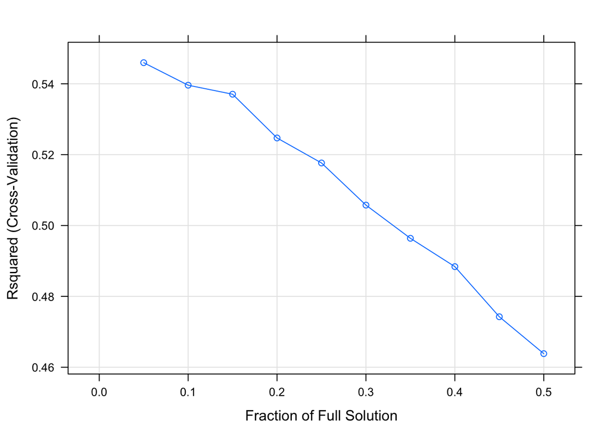

```r
plot(lassoFit)
```

```r
set.seed(1)
enetFit <- train(x=X.train,
                 y=y.train,
                 method='enet',
                 metric='Rsquared',
                 tuneGrid=expand.grid(.fraction = seq(0, 1, by=0.1),
                                      .lambda = seq(0, 1, by=0.1)),
                 trControl=trainControl(method='cv'),
                 preProcess=c('center','scale')
                  )
enetFit
```

```
## Elasticnet
##
## 133 samples
## 388 predictors
##
## Pre-processing: centered (388), scaled (388)
## Resampling: Cross-Validated (10 fold)
## Summary of sample sizes: 120, 120, 121, 117, 120, 120, ...
## Resampling results across tuning parameters:
##
##   lambda  fraction  RMSE      Rsquared   MAE
##   0.0     0.0       15.60181        NaN  12.611993
##   0.0     0.1       11.42376  0.5244866   8.462497
##   0.0     0.2       11.28953  0.5037691   8.138117
##   0.0     0.3       11.33849  0.4941979   8.063750
##   0.0     0.4       11.31415  0.5077012   8.032148
##   0.0     0.5       11.47106  0.5110596   8.177530
##   0.0     0.6       11.58460  0.5141236   8.328732
##   0.0     0.7       11.93822  0.5042530   8.598528
##   0.0     0.8       12.24980  0.4984048   8.804733
##   0.0     0.9       12.63234  0.4900099   9.066798
##   0.0     1.0       12.98113  0.4838369   9.323084
##   0.1     0.0       15.58728        NaN  12.541629
##   0.1     0.1       11.57452  0.5161250   8.129979
##   0.1     0.2       11.29849  0.5220875   8.104234
##   0.1     0.3       11.33494  0.5197157   8.194409
##   0.1     0.4       11.50410  0.5129282   8.307087
##   0.1     0.5       11.57645  0.5146960   8.314212
##   0.1     0.6       11.77010  0.5096076   8.466451
##   0.1     0.7       12.02767  0.4994392   8.733282
##   0.1     0.8       12.33113  0.4862740   8.994356
##   0.1     0.9       12.58333  0.4734054   9.189213
##   0.1     1.0       12.81412  0.4616530   9.350956
##   0.2     0.0       15.58728        NaN  12.541629
##   0.2     0.1       11.65576  0.5189315   8.177687
##   0.2     0.2       11.55513  0.5163558   8.185351
##   0.2     0.3       11.48096  0.5258621   8.242938
##   0.2     0.4       11.50501  0.5273816   8.300840
##   0.2     0.5       11.60188  0.5265142   8.352254
##   0.2     0.6       11.70259  0.5277951   8.408166
```

[output cut: 80 more lines]

```
##   0.9     1.0       15.62762  0.5431933  11.713793
##   1.0     0.0       15.58728        NaN  12.541629
##   1.0     0.1       11.82094  0.5168027   7.955070
##   1.0     0.2       13.17423  0.5236873   8.431283
##   1.0     0.3       14.04264  0.5223904   9.607780
##   1.0     0.4       14.45523  0.5311703  10.139053
##   1.0     0.5       14.79922  0.5348529  10.582952
##   1.0     0.6       15.16617  0.5372357  11.018622
##   1.0     0.7       15.46394  0.5429774  11.337527
##   1.0     0.8       15.77025  0.5458848  11.668965
##   1.0     0.9       16.04591  0.5460360  11.968590
##   1.0     1.0       16.28403  0.5445606  12.216220
##
## Rsquared was used to select the optimal model using the largest value.
## The final values used for the model were fraction = 0.8 and lambda = 0.9.
```

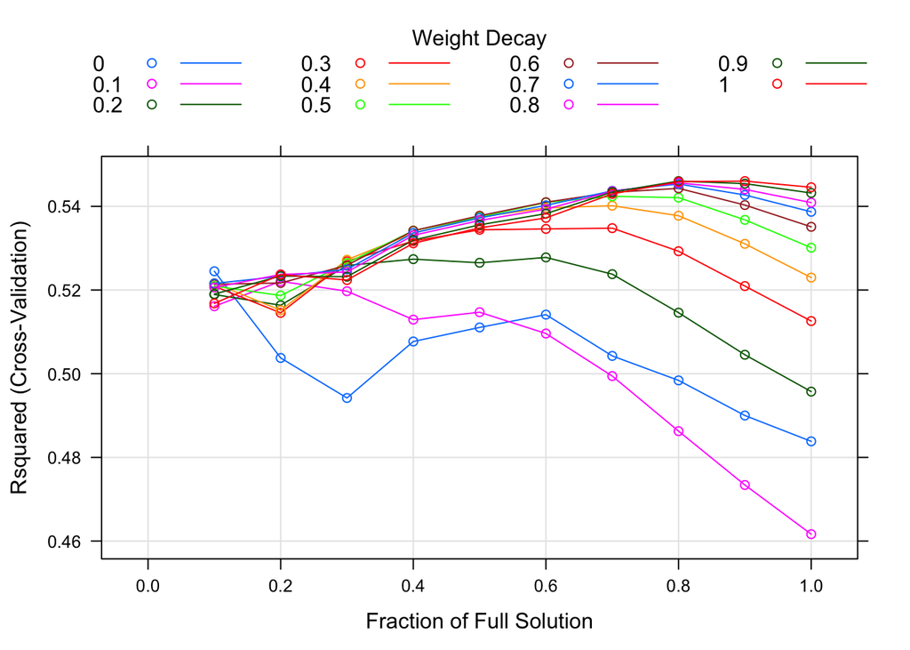

```r
plot(enetFit)
```

6. Would you recommend any of your models to replace the permeability laboratory experiment?

I would not recommend any of my models to replace the permeability laboratory experiment. The graph below of the target variable permeability shows that a majority of my results are under 5.

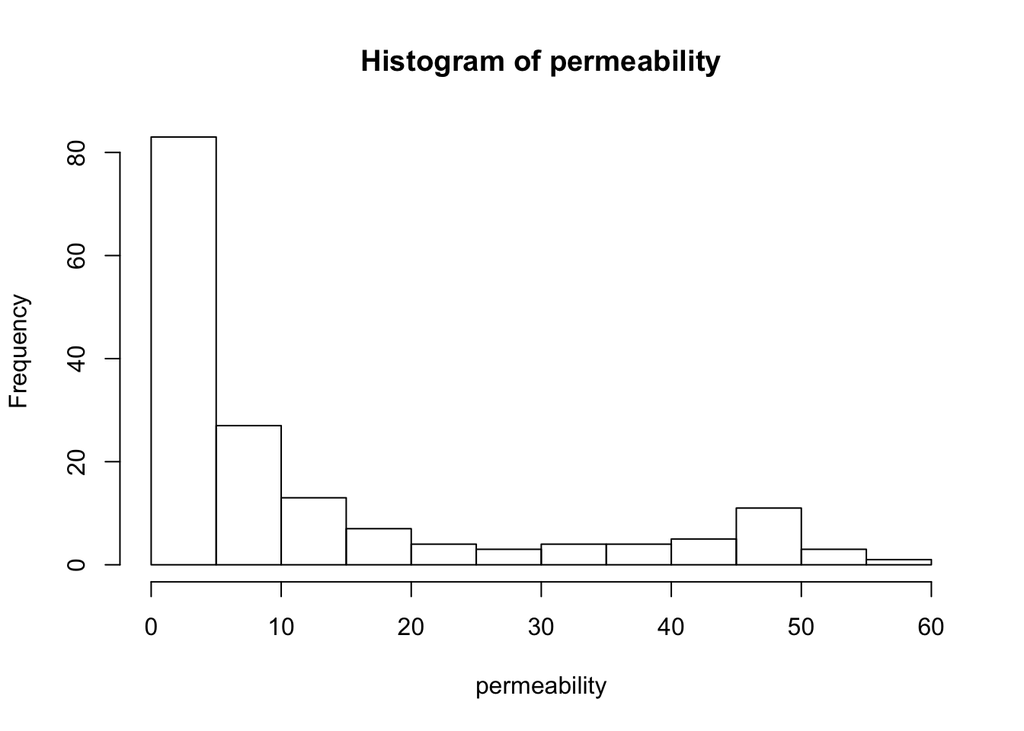

```r
hist(permeability)
```

6.3. A chemical manufacturing process for a pharmaceutical product was discussed in Sect. 1.4. In this problem, the objective is to understand the relationship between biological measurements of the raw materials (predictors), measurements of the manufacturing process (predictors), and the response of product yield. Biological predictors cannot be changed but can be used to assess the quality of the raw material before processing. On the other hand, manufacturing process predictors can be changed in the manufacturing process. Improving product yield by 1% will boost revenue by approximately one hundred thousand dollars per batch:

1. Start R and use these commands to load the data: > library(AppliedPredictiveModeling) > data(chemicalManufacturingProcess) The matrix processPredictors contains the 57 predictors (12 describing the input biological material and 45 describing the process predictors) for the 176 manufacturing runs. yield contains the percent yield for each run.

```r
library(naniar)
library(elasticnet)
library(AppliedPredictiveModeling)
data(ChemicalManufacturingProcess)
```

2. A small percentage of cells in the predictor set contain missing values. Use an imputation function to fill in these missing values (e.g., see Sect. 3.8).

I will use the ‘bagImpute’ method, which impute the missing values through bagged tree model.

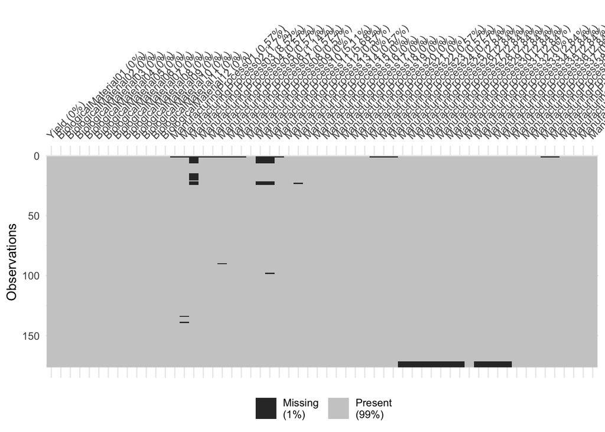

```r
vis_miss(ChemicalManufacturingProcess)
```

```r
(cmpImpute <- preProcess(ChemicalManufacturingProcess[,-c(1)], method=c('bagImpute')))
```

```
## Created from 152 samples and 57 variables
##
## Pre-processing:
##   - bagged tree imputation (57)
##   - ignored (0)
```

3. Split the data into a training and a test set, pre-process the data, and tune a model of your choice from this chapter. What is the optimal value of the performance metric?

```r
cmp <- predict(cmpImpute, ChemicalManufacturingProcess[,-c(1)])

set.seed(17)
trainRow <- createDataPartition(ChemicalManufacturingProcess$Yield, p=0.8, list=FALSE)
X.train <- cmp[trainRow, ]
y.train <- ChemicalManufacturingProcess$Yield[trainRow]
X.test <- cmp[-trainRow, ]
y.test <- ChemicalManufacturingProcess$Yield[-trainRow]
```

```r
set.seed(1)
enetFit <- train(x=X.train,
                 y=y.train,
                 method='enet',
                 metric='RMSE',
                 tuneGrid=expand.grid(.fraction = seq(0, 1, by=0.1),
                                      .lambda = seq(0, 1, by=0.1)),
                 trControl=trainControl(method='cv'),
                 preProcess=c('center','scale')
                  )
```

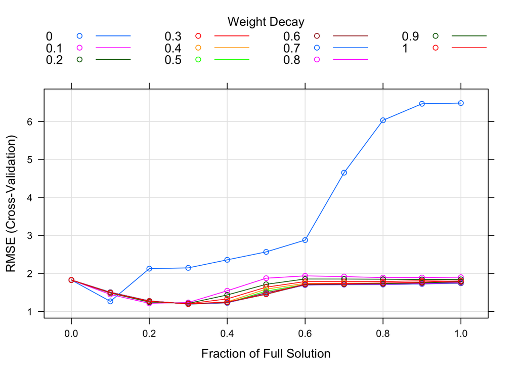

```r
plot(enetFit)
```

4. Predict the response for the test set. What is the value of the performance metric and how does this compare with the resampled performance metric on the training set?

The test set RMSE is 1.0635052. This is lower than the resampled performance metric (cross validated RMSE) on the training set. So the test set result appears to be better than the training set result.

```r
enetPred <- predict(enetFit, newdata=X.test)
(predResult <- postResample(pred=enetPred, obs=y.test))
```

```
##      RMSE  Rsquared       MAE
## 1.0635052 0.7133951 0.9061537
```

5. Which predictors are most important in the model you have trained? Do either the biological or process predictors dominate the list?

It appears that ManufacturingProcess are more important. 12 out of the 20 ManufacturingProcess dominate the list.

```r
(coeffs <- predict.enet(enetFit$finalModel, s=enetFit$bestTune[1, "fraction"], type="coef", mode="fraction")$coefficients)
```

```
##   BiologicalMaterial01   BiologicalMaterial02   BiologicalMaterial03
##             0.00000000             0.05598129             0.04140526
##   BiologicalMaterial04   BiologicalMaterial05   BiologicalMaterial06
##             0.01450012             0.00000000             0.05611269
##   BiologicalMaterial07   BiologicalMaterial08   BiologicalMaterial09
##             0.00000000             0.00000000             0.00000000
##   BiologicalMaterial10   BiologicalMaterial11   BiologicalMaterial12
##             0.00000000             0.00000000             0.00000000
## ManufacturingProcess01 ManufacturingProcess02 ManufacturingProcess03
##             0.00000000             0.00000000             0.00000000
## ManufacturingProcess04 ManufacturingProcess05 ManufacturingProcess06
##             0.00000000             0.00000000             0.11810972
## ManufacturingProcess07 ManufacturingProcess08 ManufacturingProcess09
##             0.00000000             0.00000000             0.33963103
## ManufacturingProcess10 ManufacturingProcess11 ManufacturingProcess12
##             0.00000000             0.06735213             0.00000000
## ManufacturingProcess13 ManufacturingProcess14 ManufacturingProcess15
##            -0.25737477             0.00000000             0.00000000
## ManufacturingProcess16 ManufacturingProcess17 ManufacturingProcess18
##             0.00000000            -0.17911214             0.00000000
## ManufacturingProcess19 ManufacturingProcess20 ManufacturingProcess21
##             0.00000000             0.00000000             0.00000000
## ManufacturingProcess22 ManufacturingProcess23 ManufacturingProcess24
##             0.00000000             0.00000000             0.00000000
## ManufacturingProcess25 ManufacturingProcess26 ManufacturingProcess27
##             0.00000000             0.00000000             0.00000000
## ManufacturingProcess28 ManufacturingProcess29 ManufacturingProcess30
##             0.00000000             0.00000000             0.00000000
## ManufacturingProcess31 ManufacturingProcess32 ManufacturingProcess33
##             0.00000000             0.58932783             0.00000000
## ManufacturingProcess34 ManufacturingProcess35 ManufacturingProcess36
##             0.00000000             0.00000000            -0.26292779
## ManufacturingProcess37 ManufacturingProcess38 ManufacturingProcess39
##             0.00000000             0.00000000             0.00000000
## ManufacturingProcess40 ManufacturingProcess41 ManufacturingProcess42
##             0.00000000             0.00000000             0.00000000
## ManufacturingProcess43 ManufacturingProcess44 ManufacturingProcess45
##             0.00000000             0.00000000             0.00000000
```

```r
coeffs.sorted <- abs(coeffs)
coeffs.sorted <- coeffs.sorted[coeffs.sorted>0]
(coeffs.sorted <- sort(coeffs.sorted, decreasing = T))
```

```
## ManufacturingProcess32 ManufacturingProcess09 ManufacturingProcess36
##             0.58932783             0.33963103             0.26292779
## ManufacturingProcess13 ManufacturingProcess17 ManufacturingProcess06
##             0.25737477             0.17911214             0.11810972
## ManufacturingProcess11   BiologicalMaterial06   BiologicalMaterial02
##             0.06735213             0.05611269             0.05598129
##   BiologicalMaterial03   BiologicalMaterial04
##             0.04140526             0.01450012
```

```r
varImp(enetFit)
```

```
## loess r-squared variable importance
##
##   only 20 most important variables shown (out of 57)
##
##                        Overall
## ManufacturingProcess32  100.00
## ManufacturingProcess13   95.65
## ManufacturingProcess17   82.51
## BiologicalMaterial06     78.16
## ManufacturingProcess36   77.31
## ManufacturingProcess09   76.29
## ManufacturingProcess06   66.56
## BiologicalMaterial03     66.46
## BiologicalMaterial12     65.45
## ManufacturingProcess31   65.10
## BiologicalMaterial02     58.67
## ManufacturingProcess11   54.80
## BiologicalMaterial04     50.25
## ManufacturingProcess33   49.10
## ManufacturingProcess30   47.12
## ManufacturingProcess18   43.20
## ManufacturingProcess29   42.36
## BiologicalMaterial11     41.49
## BiologicalMaterial08     40.09
## BiologicalMaterial09     39.56
```

6. Explore the relationships between each of the top predictors and the response. How could this information be helpful in improving yield in future runs of the manufacturing process?

Elasticnet is a linear regression model. The coefficients directly explain how the predictors affect the target in this case yields. I would develop coefficients to have the maximum yield return.

```r
coeffs.mp <- coeffs.sorted[grep('ManufacturingProcess', names(coeffs.sorted))] %>% names() %>% coeffs[.]
coeffs.mp[coeffs.mp>0]
```

```
## ManufacturingProcess32 ManufacturingProcess09 ManufacturingProcess06
##             0.58932783             0.33963103             0.11810972
## ManufacturingProcess11
##             0.06735213
```

```r
coeffs.mp[coeffs.mp<0]
```

```
## ManufacturingProcess36 ManufacturingProcess13 ManufacturingProcess17
##             -0.2629278             -0.2573748             -0.1791121
```